None

# Tutorial scikit-learn

scikit-learn é uma biblioteca python de código aberto utilizada para criação de modelos de machine learning. Atualmente é uma das principais bibliotecas utilizadas na ciência de dados, isso ocorre porque o scikit tem uma grande variedade de algoritmos para diversos tipos de modelo e tem uma quantidade de exemplos e documentos para esses modelos.

Introdução para machine learning - O machine learning é um subcampo de inteligêcia artificial que tem como principal abordagem a de aprender através da experiência para encontrar padrões em conjunto de dados. Um exemplo do machine learning no nosso dia a dia é o algoritmo de sugestões de filmes do netflix, o indentificador de spam no e-mail.

Existem três principais categorias de machine learning: supervisionado, não-supervisionado e por reforço.

supervisionado - O supervisionamento é feito quando a partir de um conjunto de dados rotulados previamente definido, deseja-se encontrar uma função que seja capaz de predizer rótulos desconhecidos.

não-supervisionado - Nesse tipo de aprendizagem o conjunto de dados utilizado não possui nenhum tipo de rótulo. O objetivo desse tipo de aprendizagem é descobrir similaridades entre os objetos analisados a fim de detectar similaridades e anomalias.

Reforço - Nesse tipo de aprendizagem a máquina tenta aprender qual é a melhor ação a ser tomada a partir das circunstâncias em que essa ação será executada

# Conceitos importantes

overfitting - Ocorre quando o modelo está bem ajustado aos dados de treinamento, mas não generaliza tão bem.

underfitting - Ocorre quando o modelo é muito simples para estrutura de dados subjacentes, ou seja o modelo não generalizava tanto os dados de treinamento como os de teste

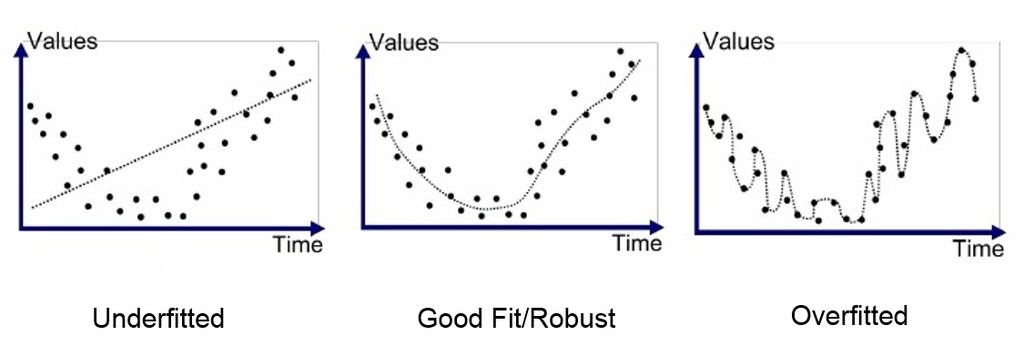

# Divisão do Dataset

Divisão do Dataframe - Sempre que se construir um modelo é importante que se separe o DataFrame em pelo menos duas partes treino e teste, para que se garanta que o modelo não ficou viciado nos dados após o seu treinamento .Normalmente se separa na proporção de 70% pra treino e 30% pra teste, mas isso fica a escolha da pessoa.

No Scikit há um método que separa o dataset de maneira mais simples, mas também é possível de ser feito com pandas

from sklearn.model_selection import train_test_split

x_train,x_test,y_train,y_test=train_test_split(x,y,test_size=0.3)

# Pré-processamento

Sklearn.preprocessing - O pré-processamento nada mais é do que o processo de preparação, organização e estruturação dos dados.

Variáveis numéricas - Nos dados numéricos sáo utilizadas técnicas para reescalar os dados, pois no dataset utilizado pode ter diversos valores em escalas diferentes e essas diferenças podem prejudicar na qualidade do treino do modelo.

standardScaler - reescala as features removendo a média (média = 0) e tornando o desvio padrao igual a 1. Desta forma, as features são paradronizadas, tornando-as mais facéis manejáveis para nossos modelos.

from sklearn.preprocessing import StandardScaler

scaler=StandardScaler()

train_s=scaler.fit_transform(x_train)

test_s=scaler.transform(x_test)

MinMaxScaler - Reescala cada coluna de forma individual em um determinado intervalo que normalmente é entre 0 e 1 mas se tiver dados com valores negativos pode variar entre -1 e 1. Colocar os dados na mesma escala faz com que os modelos trabalhem de forma mais eficiente.

from sklearn.preprocessing import MinMaxScaler

scaler=MinMaxScaler(feature_range=(0, 1))

train_s=scaler.fit_transform(x_train)

test_s=scaler.fit_transform(x_test)

RobustScaler - Diferente do MinMax e do Standard o Robust atua com a combinação dos quartis e isso nos garante um bom controle dos outliers. No entanto, ele não impede que tenha outliers mas reduz o seu impacto.

from sklearn.preprocessing import RobustScaler

scaler=RobustScaler()

train_s=scaler.fit_transform(x_train)

test_s=scaler.fit_transform(x_test)

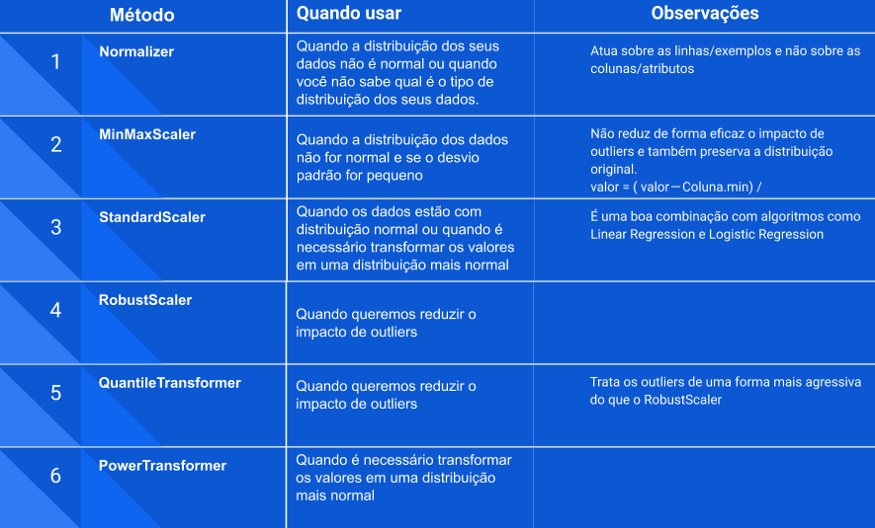

Variáveis Categóricas - Nos dados categóricos se utiliza métodos de pré-processamentos para transformá-los em dados numéricos pois existe diversos algoritmos que não conseguem trabalhar com dados categóricos. Em problemas de classificação é muito comum encontrar na variável independente dados categóricos, um exemplo disso é em fazer classificador de cores que na variável independente tem como cores vermelho, azul e verde e utiliza-se métodos de pré-processamentos para transforma-los em númericos, retornando-os como [0,1,2].

Para tratar de variáveis categóricas é usada a combinação dos métodos LabelEnconder e OneotEnconding. O Label irá transformar os nomes em números e depois utiliza-se o OneHotEncoder para transformar esses números em novas colunas do dataset.

aplicando o LabelEncoder e OneotEnconding:from sklearn.preprocessing import LabelEncoder,OnehotEncoder

label=LabelEncoder()

ohe=OneHotEncoder(categorical_features = [0])

x_l=label.fit_transform(x)

x_o=ohe.fit_transform(x_l)

# Modelos

Regressão - tem como objetivo prever o valor numérico de algo específico como o valor da ação de alguma empresa. Para os modelos de regressão irei mostrar a regressão linear que é o modelo mais simples. Existem diversos modelos da regressão linear que são bem mais complexos como a floresta aleatória.

Regressão linear - A equação da regressão linear estima uma condicional de variável y, com os dados de uma variável x, essa equação indica os pontos fortes dessa relação e quantifica este relacionamento.

Aplicando a regressão: from sklearn.linear_model import LinearRegression

lr=LinearRegression()

lr.fit(x_train,y_train)

lr.coef_ - para observar os coeficientes

lr.intercept_ - ponto de intercepção no eixo y

lr.predict(x_test)- observar o que foi previsto pelo modelo

Classificação - Tem como objetivo prever uma classe, dentro das possibilidades limitadas existentes. Nesse tutorial iremos mostrar a regressão logística que é um dos modelos mais simples para problemas de classificação.

Regressão Logística - A regressão logística estima a probabilidade a ocrrência de uma classe a partir de observações dos dados de x. Normalmente esse modelo é usado para problemas de duas classes mas também pode ser usados para problemas de multiclasses.

Aplicando a regressão: from sklearn.linear_model import LogisticRegression

lg=LogisticRegression()

lg.fit(x_train,y_train)

lg.coef_ - para observar os coeficientes

lg.intercept_ - ponto de intercepção no eixo y

lg.predict(x_test)- observar o que foi previsto pelo modelo

# validação cruzada

A validação cruzada k-fold consiste em dividir o dados de treino em k partes. Ultiliza-se as k-1 partes para ajustar-se ao modelo usado e a parte restante para a validação. Esse processo é repetido k vezes e, em seguida, os resultados são combinados obtendo a médias dos erros obtidos. Esse método é utilizado para garantir que não esteja ocorrendo sobreposição no modelo e para medir a capacidade de predição do modelo.

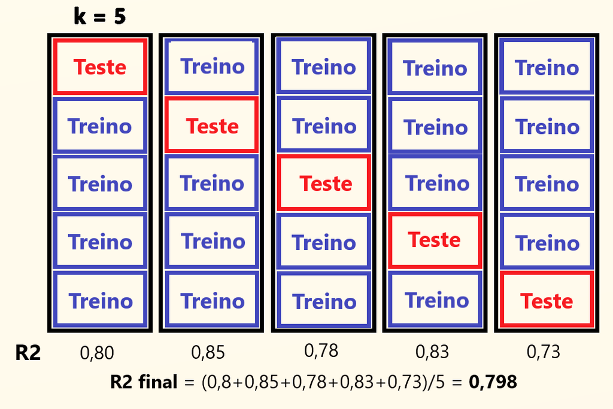

aplicando a validação cruzada: from sklearn.model_selection import cross_val_score

cv=cross_val_score(modelo,x_train,y_train,cv=(quantidade de k),scoring='métrica utilizada')

cv.mean()- irá mostrar a pontuação média

# GridSearchcv

O GridSearchcv é uma maneira simples de se conseguir descobrir quais são os melhores hiperparâmetros para o modelo. Ele consegue descobrir a melhor combinação calculando todas as combinações possíveis de hiperparâmetros por meio da validação cruzada.

Aplicando GridSearchCv: from sklearn.model_selection import GridSearchCv

param_grid={dicionário contendo os hiperparâmetros}

lr=LinearRegression()

grid=GridSearchCv(lr,param_grid,cv=K,scoring='métrica utilizada')

grid.fit(x_train,y_train)

grid.best*param* - para ver os melhores hiperparâmetros

grid.best*estimators* - para ver a melhor combinação para o modelo

grid.best*score* - para ver a melhor pontuação

grid.results*cv* - para ver o resultado de todas as combinações

# Avaliando o modelo

Para avaliar o modelo são usadas métricas as quais podem dizer quão bem o modelo está avaliando, elas podem avaliar mostrando uma pontuação no intevalo de 0 a 1, sua acurácia, seu desvio padrão dentre outras formas.

Para modelos de regressão:

r2_score - O R² mede quanto do erro de previsão é eliminado

from sklearn.metrics import r2_score

r2_score(pred,y_test)

rmse - A Raiz Quadrada do Erro Quadrático Médio, que nada mais é que a diferença entre valor que foi previsto pelo seu modelo e o valor real que foi observado.

from sklearn.metrics import mean_squared_error

np.sqrt(mean_squared_error(pred,y_test))

Para modelos de classifcação:

accuracy_score - proximidade entre o valor previsto e o valor real.

from sklearn.metrics import accuracy_score

accuraracy_score(pred,y_train)

confusion_matrix - é uma medição de desempenho para o problema de classificação de aprendizado de máquina em que a saída pode ser de duas ou mais classes. É uma tabela com 4 combinações diferentes de valores previstos e reais.

from sklearn.metrics import confusion_matrix

confunsion_matrix(pred,y_test)

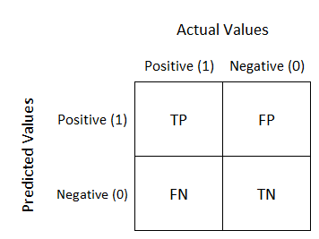